# Lab 3: Mine Crafting

As with previous labs, be sure to submit only the `lab3.ipynb` and `lab3.html` version of the lab in your github `Lab3` folder. No more, and no less.

## Introduction

Imagine you are a scientist for a mining company that operates a vertical mine at the Earth's equator. This is one of the deepest mines on Earth; it's roughly 4 km to the bottom of the shaft. Your boss proposes to measure the vertical depth of the shaft by dropping a 1 kg test mass and accurately measuring the time to hit the bottom.

You will be guided in your investigations below and submit your report in the form of this notebook. Be sure to be quantitative in nature, produce highly polished plots, with appropriate titles, units, etc.

A table of relevant physical constants is below. Good luck!

| Quantity | Value |
| --- | --- |
| Gravitational Constant ($G$) | $6.6743 \times 10^{-11}$ m$^3$/kg/s$^2$ |
| Gravitational Acceleration ($g_o$) | 9.81 m/s$^2$ (approximate) |
| Mass of the Earth ($M_{\oplus}$) | $5.972 \times 10^{24}$ kg |
| Mass of the Moon ($M_{m}$) | $7.35 \times 10^{22}$ kg |
| Radius of the Earth ($R_{\oplus}$) | 6378.1 km |
| Radius of the Moon ($R_{m}$) | 1738.1 km |
| Earth's Rotation Rate at the Equator | $7.272 \times 10^{-5} $ rad/s |

```python
import numpy as np
import matplotlib.pyplot as plt
from scipy.integrate import solve_ivp
from scipy.integrate import quad
from scipy.fft import fft
from scipy.fft import fftfreq

from scipy import constants as cn
G = cn.G # m^2/kg/s^2
g = cn.g # m/s^2
M_e = 5.972e24 # kg
M_m = 7.35e22 # kg
R_e = 6378.1e3 # m
R_m = 1738.1e3 # m
Rot_e = 7.272e-5 # rad/s
```

## Part 1: The Ideal Case

In this section and the following sections, we calculate the time for the 1 kg test mass to reach the bottom of the mineshaft under a series of increasingly complex assumptions. Remember that a projectile experiencing a constant gravitational force, plus a drag force, obeys the following second order differential equation:

$$ \frac{d^2y}{dt^2} = -g + \alpha \left| \frac{dy}{dt} \right|^{\gamma} \tag{1} $$

where $t$ is time, $y$ is the height, $g$ is the gravitational acceleration, $\alpha$ is the drag coefficient, and $\gamma$ is the speed dependence of the drag. For example, for $\gamma=2$, the drag force grows proportionally to the speed *squared*. **Hint**: pay particular attention to the sign conventions in your implementation! The drag, by definition, should *oppose* the direction of motion.

1. First, make a simple calculation of how long a test mass would take to reach the bottom of the 4km shaft assuming no drag. This is the simple free-fall algebraic expression you know from PHYS 171.
2. Next, reduce (1) into a *system* of coupled first order differential equations by setting the velocity $v = dy/dt$.
3. Numerically solve (1) using `solve_ivp` assuming $\alpha=0$. Plot the position and velocity as a function of time.  
   Draw a horizontal dashed line at the depth of the bottom of the shaft, to make it easy to see. Make the plot look nice, including displaying the position on the left axes, and plotting the velocity on a second right axis, using matplotlib `twinx` capability.  
   In your notebook, label this figure clearly as **Figure 1**.
4. Using the `events` detection capability of `solve_ivp`, calculate the time at which the mass hits the bottom of the shaft in the case of zero drag ($\alpha=0$). Compare this to your analytic calculation and discuss any differences you might see.

```python
#part 1
x = 4000 #meters
#get analytical solution by rearranging kinematic equation x=gt^2
t_calc = (2*x/g)**0.5
print(f'Time to bottom: {t_calc:.3f}s')
```

```
Time to bottom: 28.562s
```

$$\frac{d^2y}{dt^2} = -g + \alpha \left| \frac{dy}{dt} \right|^{\gamma}$$ Using $v = dy/dt$ we can reduce to the system of the following two equations $$\frac{dy}{dt} = v$$ $$\frac{dv}{dt} = -g+ \alpha \left| v \right|^{\gamma}$$

[output not shown]

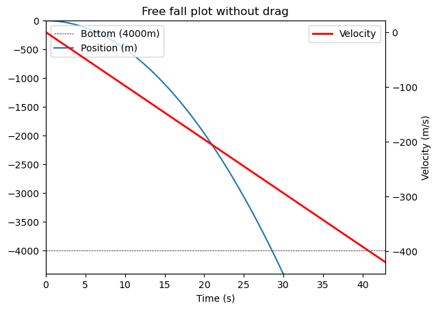

```python
#part 3
#define the equation to solve
def motion(t, init, g=g, gamma=2, a=0.):
    y, v = init
    dydt=v
    dvdt = -g + a*np.abs(v)**gamma
    return dydt, dvdt

#set up initial conditions
y0 = 0
v0 = 0
init0 = (y0, v0)
depth = -4000

#set up the time span based on calculated rresult above
t_span = (0, t_calc*1.5)
t_eval = np.linspace(0, t_calc*1.5, 1000)

soln = solve_ivp(motion, t_span, y0=init0, args=(g,2,0), t_eval=t_eval)
print(soln)


#plot the data
fig, ax1 = plt.subplots()
ax1.axhline(depth, linestyle='--', color='black', linewidth=0.5, label='Bottom (4000m)')

ax1.plot(soln.t, soln.y[0], label='Position (m)')
ax1.set_xlim(0, soln.t[-1])
ax1.set_ylim(depth*1.1, 0)
ax1.legend(loc='upper left')
ax1.set_xlabel('Time (s)')

ax2 = ax1.twinx()
ax2.set_ylabel('Velocity (m/s)')
ax2.plot(soln.t, soln.y[1], color='red', linewidth=2, label='Velocity')
ax2.legend(loc='upper right')

plt.title('Free fall plot without drag')
```

```python
#part 4
#define the event
def hit_bottom(t, init, g=g, gamma=2, alpha=0.):
    return init[0] - depth

#run the solver with the event
soln_event = solve_ivp(motion, t_span, init0, args=(g, 2, 0), events=hit_bottom, dense_output=True)
t_num = soln_event.t_events[0][0]
print(f"Time to bottom (numerical): {t_num:.3f} s")
print(f"Time to bottom (analytical): {t_calc:.3f} s")
if np.isclose(t_num, t_calc):
    print('The values are the same')
else:
    print('The values are not the same')
```

```
Time to bottom (numerical): 28.562 s
Time to bottom (analytical): 28.562 s
The values are the same
```